The loan approval prediction dataset contains the details of applicants who have applied for property loan.

The bank decides the approval of the loan based on factors such as applicant income, loan amount, credit history etc.

The goal of the project is to build a Machine Learning Model that succesfully makes decision regarding loan approval.

# Data Attributes

Loan_ID: A unique loan ID

Gender: Gender of the Applicant

Married: Yes/No

Dependents: No.of dependants of the applicant

Education: Education ( Graduate/Undergraduate)

Self_Employed: Yes/No

ApplicantIncome: Income of the Applicant

CoapplicantIncome: Co-applicant income.

LoanAmount: Loan amount in thousands.

Loan_Amount_Term: Terms of the loan in months.

Credit_History: Credit history meets guidelines.

Property_Area: Applicants are living either Urban, Semi-Urban or Rural.

Loan_Status: Loan approved (Y/N)

```python
#Importing Necessary libraries

import pandas as pd #Data processing

import numpy as np #linear algebra

import matplotlib.pyplot as plt #visualization

import seaborn as sns #visualization

import warnings
warnings.filterwarnings("ignore") #filter out warning messsages

from sklearn.preprocessing import LabelEncoder #encoding categorical labels

from sklearn.preprocessing import StandardScaler #ensure features have similiar scale

from sklearn.model_selection import train_test_split #features engineering

from sklearn.linear_model import LogisticRegression #classification

from sklearn.ensemble import RandomForestClassifier #randomforest classification

from sklearn.tree import DecisionTreeClassifier #decsiontreeclassification

from sklearn.metrics import accuracy_score, classification_report, confusion_matrix #evaluate the prediction
```

```python
#Importing the dataset

file_path = "D:\\VV_Arbeit\\Data_Analytics_Portfolio\\Projects\\Loan_Approval\\loan_data.csv"
data = pd.read_csv(file_path)
```

```python
data.info()
```

```
<class 'pandas.core.frame.DataFrame'>
RangeIndex: 381 entries, 0 to 380
Data columns (total 13 columns):
 #   Column             Non-Null Count  Dtype
---  ------             --------------  -----
 0   Loan_ID            381 non-null    object
 1   Gender             376 non-null    object
 2   Married            381 non-null    object
 3   Dependents         373 non-null    object
 4   Education          381 non-null    object
 5   Self_Employed      360 non-null    object
 6   ApplicantIncome    381 non-null    int64
 7   CoapplicantIncome  381 non-null    float64
 8   LoanAmount         381 non-null    int64
 9   Loan_Amount_Term   370 non-null    float64
 10  Credit_History     351 non-null    float64
 11  Property_Area      381 non-null    object
 12  Loan_Status        381 non-null    object
dtypes: float64(3), int64(2), object(8)
memory usage: 38.8+ KB
```

```python
#Exploratory Data Analysis

data.sample(8,random_state = 112)
```

|  | Loan_ID | Gender | Married | Dependents | Education | Self_Employed | ApplicantIncome | CoapplicantIncome | LoanAmount | Loan_Amount_Term | Credit_History | Property_Area | Loan_Status |
| --- | --- | --- | --- | --- | --- | --- | --- | --- | --- | --- | --- | --- | --- |
| 128 | LP001711 | Male | Yes | 3+ | Graduate | No | 3430 | 1250.0 | 128 | 360.0 | 0.0 | Semiurban | N |
| 326 | LP002670 | Female | Yes | 2 | Graduate | No | 2031 | 1632.0 | 113 | 480.0 | 1.0 | Semiurban | Y |
| 31 | LP001136 | Male | Yes | 0 | Not Graduate | Yes | 4695 | 0.0 | 96 | NaN | 1.0 | Urban | Y |
| 323 | LP002643 | Male | Yes | 2 | Graduate | No | 3283 | 2035.0 | 148 | 360.0 | 1.0 | Urban | Y |
| 151 | LP001811 | Male | Yes | 0 | Not Graduate | No | 3406 | 4417.0 | 123 | 360.0 | 1.0 | Semiurban | Y |
| 142 | LP001768 | Male | Yes | 0 | Graduate | NaN | 3716 | 0.0 | 42 | 180.0 | 1.0 | Rural | Y |
| 229 | LP002181 | Male | No | 0 | Not Graduate | No | 6216 | 0.0 | 133 | 360.0 | 1.0 | Rural | N |
| 300 | LP002505 | Male | Yes | 0 | Graduate | No | 4333 | 2451.0 | 110 | 360.0 | 1.0 | Urban | N |

```python
data.head()
```

|  | Loan_ID | Gender | Married | Dependents | Education | Self_Employed | ApplicantIncome | CoapplicantIncome | LoanAmount | Loan_Amount_Term | Credit_History | Property_Area | Loan_Status |
| --- | --- | --- | --- | --- | --- | --- | --- | --- | --- | --- | --- | --- | --- |
| 0 | LP001003 | Male | Yes | 1 | Graduate | No | 4583 | 1508.0 | 128 | 360.0 | 1.0 | Rural | N |
| 1 | LP001005 | Male | Yes | 0 | Graduate | Yes | 3000 | 0.0 | 66 | 360.0 | 1.0 | Urban | Y |
| 2 | LP001006 | Male | Yes | 0 | Not Graduate | No | 2583 | 2358.0 | 120 | 360.0 | 1.0 | Urban | Y |
| 3 | LP001008 | Male | No | 0 | Graduate | No | 6000 | 0.0 | 141 | 360.0 | 1.0 | Urban | Y |
| 4 | LP001013 | Male | Yes | 0 | Not Graduate | No | 2333 | 1516.0 | 95 | 360.0 | 1.0 | Urban | Y |

```python
data.describe()
```

|  | ApplicantIncome | CoapplicantIncome | LoanAmount | Loan_Amount_Term | Credit_History |
| --- | --- | --- | --- | --- | --- |
| count | 381.000000 | 381.000000 | 381.000000 | 370.000000 | 351.000000 |
| mean | 3579.845144 | 1277.275381 | 104.986877 | 340.864865 | 0.837607 |
| std | 1419.813818 | 2340.818114 | 28.358464 | 68.549257 | 0.369338 |
| min | 150.000000 | 0.000000 | 9.000000 | 12.000000 | 0.000000 |
| 25% | 2600.000000 | 0.000000 | 90.000000 | 360.000000 | 1.000000 |
| 50% | 3333.000000 | 983.000000 | 110.000000 | 360.000000 | 1.000000 |
| 75% | 4288.000000 | 2016.000000 | 127.000000 | 360.000000 | 1.000000 |
| max | 9703.000000 | 33837.000000 | 150.000000 | 480.000000 | 1.000000 |

```python
#Checking for missing values

data.isnull().sum()
```

```
Loan_ID               0
Gender                5
Married               0
Dependents            8
Education             0
Self_Employed        21
ApplicantIncome       0
CoapplicantIncome     0
LoanAmount            0
Loan_Amount_Term     11
Credit_History       30
Property_Area         0
Loan_Status           0
dtype: int64
```

Missing values are identified in the dataset.

Coloumns that contain missing value include

Gender(5, Categorical), Dependents(8,Object),Self-Employed(21,Object),

Loan_amount_term(11,float),Credit_history(30,)

```python
#Handling missing values

# Filing missing values with the mode for Gender Coloumn
data['Gender'].fillna(data['Gender'].mode()[0], inplace=True)

#Filling missing values for Dependents
# Fill missing values with the mode
data['Dependents'].fillna(data['Dependents'].mode()[0], inplace=True)

#Filling missing value for Self-Employed
#Filling missing values with the mode
data['Self_Employed'].fillna(data['Self_Employed'].mode()[0], inplace=True)

#Filling missing values for Loan_amount_term
# Filling missing values with the mean
data['Loan_Amount_Term'].fillna(data['Loan_Amount_Term'].mean(), inplace=True)

#Filling missing value for Credit history
#Filling missing values with the mean
data['Credit_History'].fillna(data['Credit_History'].mean(), inplace=True)
```

```python
#Checking for missing values

data.isnull().sum()
```

```
Loan_ID              0
Gender               0
Married              0
Dependents           0
Education            0
Self_Employed        0
ApplicantIncome      0
CoapplicantIncome    0
LoanAmount           0
Loan_Amount_Term     0
Credit_History       0
Property_Area        0
Loan_Status          0
dtype: int64
```

All the missing values are handled using statistical methods ( Mean and Mode)

```python
data.sample(8,random_state=112)
```

|  | Loan_ID | Gender | Married | Dependents | Education | Self_Employed | ApplicantIncome | CoapplicantIncome | LoanAmount | Loan_Amount_Term | Credit_History | Property_Area | Loan_Status |
| --- | --- | --- | --- | --- | --- | --- | --- | --- | --- | --- | --- | --- | --- |
| 128 | LP001711 | Male | Yes | 3+ | Graduate | No | 3430 | 1250.0 | 128 | 360.000000 | 0.0 | Semiurban | N |
| 326 | LP002670 | Female | Yes | 2 | Graduate | No | 2031 | 1632.0 | 113 | 480.000000 | 1.0 | Semiurban | Y |
| 31 | LP001136 | Male | Yes | 0 | Not Graduate | Yes | 4695 | 0.0 | 96 | 340.864865 | 1.0 | Urban | Y |
| 323 | LP002643 | Male | Yes | 2 | Graduate | No | 3283 | 2035.0 | 148 | 360.000000 | 1.0 | Urban | Y |
| 151 | LP001811 | Male | Yes | 0 | Not Graduate | No | 3406 | 4417.0 | 123 | 360.000000 | 1.0 | Semiurban | Y |
| 142 | LP001768 | Male | Yes | 0 | Graduate | No | 3716 | 0.0 | 42 | 180.000000 | 1.0 | Rural | Y |
| 229 | LP002181 | Male | No | 0 | Not Graduate | No | 6216 | 0.0 | 133 | 360.000000 | 1.0 | Rural | N |
| 300 | LP002505 | Male | Yes | 0 | Graduate | No | 4333 | 2451.0 | 110 | 360.000000 | 1.0 | Urban | N |

```python
#Converting 'Loan Status' Coloumn from Object to Int to build model

mapping = {'N': 0, 'Y': 1,}

# Replace categorical values in the 'Loan_status' column with numerical values
data['Loan_Status'] = data['Loan_Status'].replace(mapping).astype('int64')
```

```python
#Converting 'Loan Status' Coloumn from float to Int to build model

mapping = {'1.0': 1, '0': 0,}

# Replace categorical values in the 'Loan_status' column with numerical values
data['Credit_History'] = data['Credit_History'].replace(mapping).astype('int64')
```

```python
#Output of the code

data.info()
```

```
<class 'pandas.core.frame.DataFrame'>
RangeIndex: 381 entries, 0 to 380
Data columns (total 13 columns):
 #   Column             Non-Null Count  Dtype
---  ------             --------------  -----
 0   Loan_ID            381 non-null    object
 1   Gender             381 non-null    object
 2   Married            381 non-null    object
 3   Dependents         381 non-null    object
 4   Education          381 non-null    object
 5   Self_Employed      381 non-null    object
 6   ApplicantIncome    381 non-null    int64
 7   CoapplicantIncome  381 non-null    float64
 8   LoanAmount         381 non-null    int64
 9   Loan_Amount_Term   381 non-null    float64
 10  Credit_History     381 non-null    int64
 11  Property_Area      381 non-null    object
 12  Loan_Status        381 non-null    int64
dtypes: float64(2), int64(4), object(7)
memory usage: 38.8+ KB
```

```python
data.head(5)
```

|  | Loan_ID | Gender | Married | Dependents | Education | Self_Employed | ApplicantIncome | CoapplicantIncome | LoanAmount | Loan_Amount_Term | Credit_History | Property_Area | Loan_Status |
| --- | --- | --- | --- | --- | --- | --- | --- | --- | --- | --- | --- | --- | --- |
| 0 | LP001003 | Male | Yes | 1 | Graduate | No | 4583 | 1508.0 | 128 | 360.0 | 1 | Rural | 0 |
| 1 | LP001005 | Male | Yes | 0 | Graduate | Yes | 3000 | 0.0 | 66 | 360.0 | 1 | Urban | 1 |
| 2 | LP001006 | Male | Yes | 0 | Not Graduate | No | 2583 | 2358.0 | 120 | 360.0 | 1 | Urban | 1 |
| 3 | LP001008 | Male | No | 0 | Graduate | No | 6000 | 0.0 | 141 | 360.0 | 1 | Urban | 1 |
| 4 | LP001013 | Male | Yes | 0 | Not Graduate | No | 2333 | 1516.0 | 95 | 360.0 | 1 | Urban | 1 |

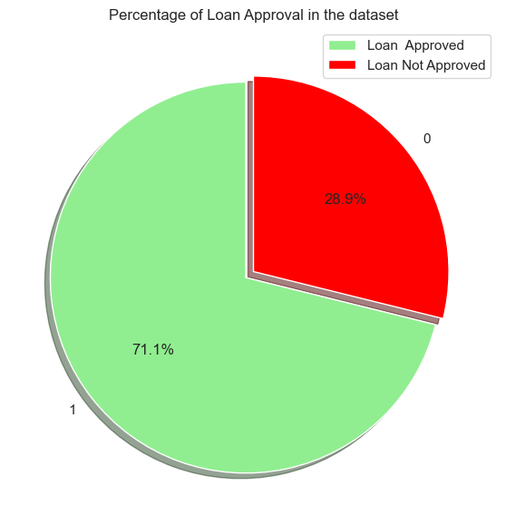

```python
#Data Visualization


#Plotting the dataset into Pie to chart to determine the frequency of approval of loan

labels =data['Loan_Status'].value_counts(sort = True).index
sizes = data['Loan_Status'].value_counts(sort = True)

colors = ["lightGreen","red"]
explode = (0.05,0)

plt.figure(figsize=(7,7))
plt.pie(sizes, explode=explode, labels=labels, colors=colors, autopct='%1.1f%%', shadow=True, startangle=90,)

plt.title('Percentage of Loan Approval in the dataset')

# Adding legend
plt.legend(labels=['Loan  Approved', 'Loan Not Approved'])

plt.show()
```

```python
#It has been understood that 71.1% of the applicants got their loan approved.
```

```python
#Exploratory Data Analysis to find determining factors for loan approval
```

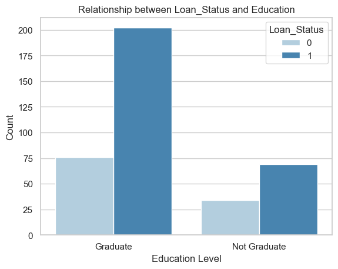

```python
#Graph_1- Relationship between Education and Loan Approval

# Filter the dataset to include only approved loans

# Calculate the percentage of loan approvals by education level

# Set the style of seaborn for better aesthetics
sns.set(style="whitegrid")

# Create a count plot to visualize the relationship between 'Loan_Status' and 'Education'
sns.countplot(x='Education', hue='Loan_Status', data=data, palette='Blues')

# Add labels and title to the plot
plt.title('Relationship between Loan_Status and Education')
plt.xlabel('Education Level')
plt.ylabel('Count')

# Show the plot
plt.show()
```

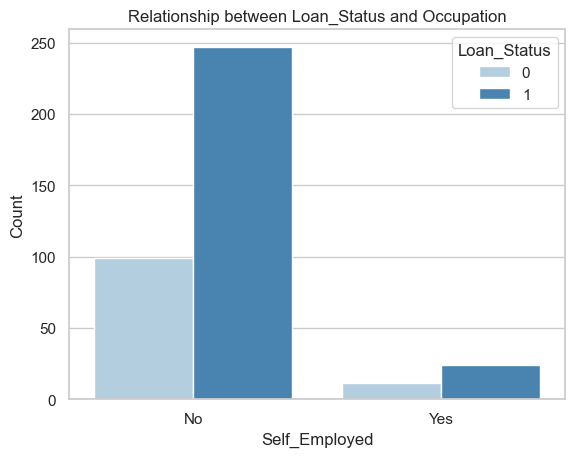

```python
#Graph_2- Relationship between Self_employed and Loan_Status

# Calculate the percentage of loan approvals by education level

# Set the style of seaborn for better aesthetics
sns.set(style="whitegrid")

# Create a count plot to visualize the relationship between 'Loan_Status' and 'Education'
sns.countplot(x='Self_Employed', hue='Loan_Status', data=data, palette='Blues')

# Add labels and title to the plot
plt.title('Relationship between Loan_Status and Occupation')
plt.xlabel('Self_Employed')
plt.ylabel('Count')

# Show the plot
plt.show()
```

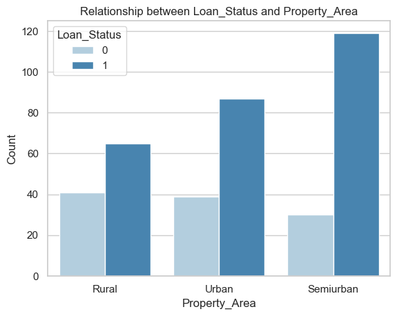

```python
#Graph_3- Relationship between Property_Area and  Loan_Status

# Calculate the percentage of loan approvals by education level

# Set the style of seaborn for better aesthetics
sns.set(style="whitegrid")

# Create a count plot to visualize the relationship between 'Loan_Status' and 'Education'
sns.countplot(x='Property_Area', hue='Loan_Status', data=data, palette='Blues')

# Add labels and title to the plot
plt.title('Relationship between Loan_Status and Property_Area')
plt.xlabel('Property_Area')
plt.ylabel('Count')

# Show the plot
plt.show()
```

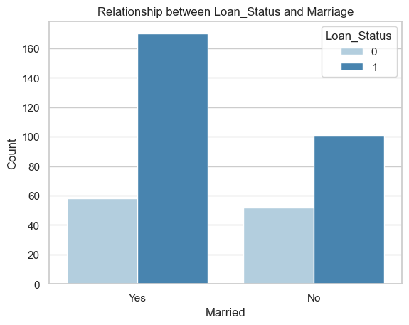

```python
#Graph_4- Relationship between Marriage and  Loan_Status

# Calculate the percentage of loan approvals by education level

# Set the style of seaborn for better aesthetics
sns.set(style="whitegrid")

# Create a count plot to visualize the relationship between 'Loan_Status' and 'Education'
sns.countplot(x='Married', hue='Loan_Status', data=data, palette='Blues')

# Add labels and title to the plot
plt.title('Relationship between Loan_Status and Marriage')
plt.xlabel('Married')
plt.ylabel('Count')

# Show the plot
plt.show()
```

Assumptions